# Starting Pitcher Analysis: Why Is He Struggling?

### Introduction

The following is an analysis report aimed at investigating why our pitcher is not having success on the field. Once we can find the problem and understand why, we can formulate suggestions on how to improve his pitching performance. The report covers batter results as well as controllable pitch design metrics such as location, movement, usage, arsenal, spin rate, etc. The next section introduces strike probability which I believe to be the foundation of our problem.

### Strike Probability (Basis of Problem)

Our analyst group developed a model that for every pitch, outputs the probability or chance of a pitch resulting in a strike. This is a fully developed and validated model based on thousands of prior MLB pitches. Values near 0 can be interpreted as pitches clearly outside the zone while values near 1 are pitches near the middle of the plate. Values around 0.5 represent the corners and edges of the strike zone that umpires may be 50/50 on calling balls and strikes. This statement can be visualized on our pitcher with the first row of three pitch charts below. From left to right, the pitches plotted represent clear strikes (probability > 0.95), clear balls (probability < 0.05), and toss-up pitches (probability > 0.4 & probability < 0.6).

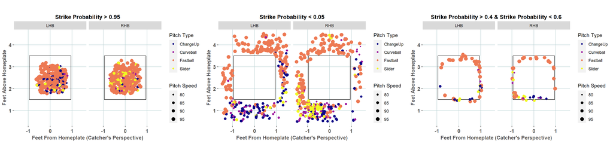

Next, let’s take a look at strike probability for our pitcher under two scenarios. First, the plot on the left shows the distribution of strike probabilities on all pitches while the right plot is only for pitches resulting in hard contact (95 mph exit velocity or greater).

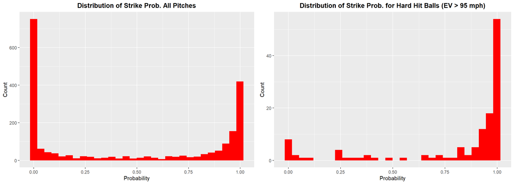

Right away, I see a red flag and an explanation as to why our pitcher is not performing well. Typically, great pitchers have control and command of the strike zone and are able to consistently paint the corners and pitch to locations not conducive to hitter success. In that case, we expect them to have many pitches with strike probabilities near 0.5. With our pitcher, his probabilities are heavily skewed along the tails. He mostly throws pitches with strike probabilities near 0 or 1. In other words, he either throws pitches down the middle of the plate or clearly outside the zone. Throwing pitches outside the zone is not necessarily bad in situations when ahead in the count or looking to fool hitters into chasing for strike 3. However, throwing too many pitches down the middle leads to hard contact. This is exactly what the right plot shows that the hard contact he allows primarily comes from pitches with very high strike probabilities. Basically, it’s easy for hitters to do damage with pitches down the middle of the plate.

### Overall Pitcher Stats

Here, we are viewing the actual hitter results to observe if my theory on poor performance based on strike probability stands. In 24 games, our pitcher gave up 127 hits, 43 extra base hits, 22 home runs, and a very high home run to fly ball ratio of 0.25. That is a significant amount of damage that hitters are making. Also, a high BABIP of 0.354 reveals either bad defense or hitters are making hard contact often as more batted balls result in hits than usual. If we compare overall results to results on pitches where the strike probability is above 0.9, then we see the pattern. Pitches with strike probability > 0.9 resulted in 68% of all hits given up, 77% of all extra base hits given up, and 82% of all home runs given up. It is worth noting that strike probability > 0.9 makes up only one-third of all pitches, but makes up most of the damage. There is strong evidence that the damage inflicted on our pitcher came from pitches located in the middle of the strike zone.

| GS | H | xBH | HR | HR_FB | K | BB | K_BB | BABIP |
| --- | --- | --- | --- | --- | --- | --- | --- | --- |
| 24 | 127 | 43 | 22 | 0.25 | 113 | 46 | 2.46 | 0.354 |

* Overall Pitcher Stats

| GS | H | xBH | HR | HR_FB | K | BB | K_BB | BABIP |
| --- | --- | --- | --- | --- | --- | --- | --- | --- |
| 24 | 86 | 33 | 18 | 0.25 | 20 | 1 | 20 | 0.366 |

* Overall Pitcher Stats for Strike Probability > 0.9

### Batter Exit Velocity

Visualizing exit velocity is another way to measure hitter success against our pitcher. The left plot is for all batted balls in play while the right plot is for all hits. In both plots, the average exit velocity is greater than the average MLB exit velocity and there are plenty of instances of very hard contact (100 mph or greater). Now, let’s get into our pitcher’s pitch design metrics.

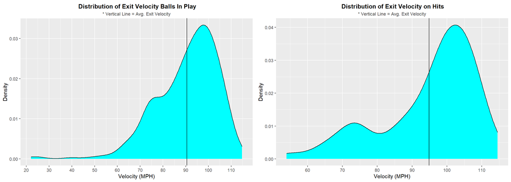

### Pitch Arsenal

Our pitcher relies heavily on the fastball while mixing in sliders, changeups, and curveballs at similar rates. However, for pitches that resulted in hard hits, 71% of them came on fastballs which means hitters are making hard contact primarily from his fastball. In the next section, I dive deeper into pitch arsenal by count.

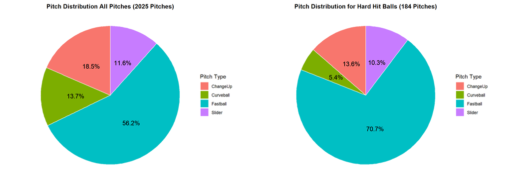

### Pitch Usage

The fastball pitch is highlighted in black as I found this to be the most glaring issue. At every pitch count, he throws the fastball most often. Typically, the correct approach when ahead 0-2 or 1-2 on a batter is to throw more off-speed or breaking ball pitches away from the strike zone to get hitters to chase pitches and strikeout. Even when ahead in the count, he still throws the fastball most often. This would be fine if he had an elite fastball as a strikeout pitch but we know that is not the case as we learned he gives up hard contact on primarily fastballs. Looking at the right plot, we see evidence of the fastball being hit hard in two strike counts. Now that we know hitters do damage on the fastball, let’s look at location of the pitches in the next section.

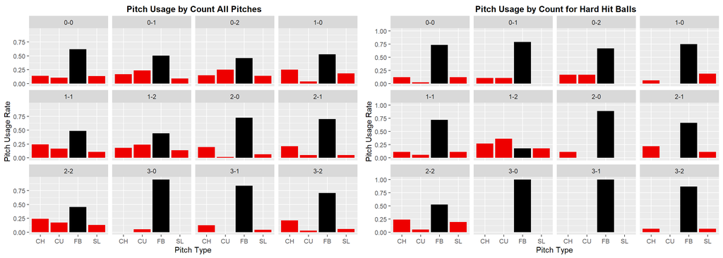

### Pitch Location

The first row of plots below visualizes the pitch location and result of the pitch when our pitcher was behind in the count (1-0,2-0,3-0,2-1,3-1) and ahead in the count (0-1,0-2,1-2,2-2). Ideally, we want to see fewer hits and pitches in the middle of the strike zone when ahead in the count than behind in the count. Purple and Yellow dots represent hits so we need to see less of those colors and more blue (outs). He actually does a decent job not giving up tons of hits when behind in the count as we see more blue (outs) than purple and yellow (hits). However, he throws too many pitches in the middle of the zone when ahead in the count which also results in more hits given up. He is capable of striking out hitters throwing off-speed below the zone but he needs to do that more often. Right now, he is leaving too many pitches in the zone for hitters to make hard contact, especially when ahead in the count. The bottom row shows his pitch location and pitch type on whiffs and hard hit batted balls. Again, he is getting hit hard from pitches (mostly fastballs) in the middle of the zone. On a positive note, he is able to get swings and misses on changeups and sliders below the zone and fastballs above the belt. We would like to see more of that instead of pounding fastballs down the zone.

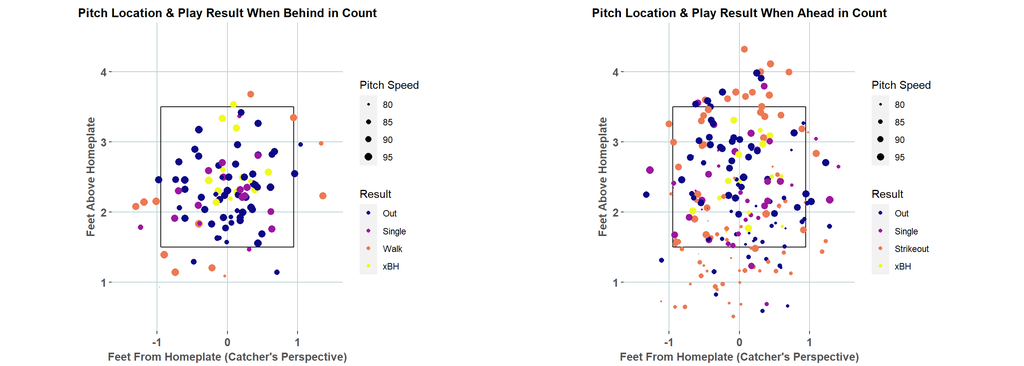

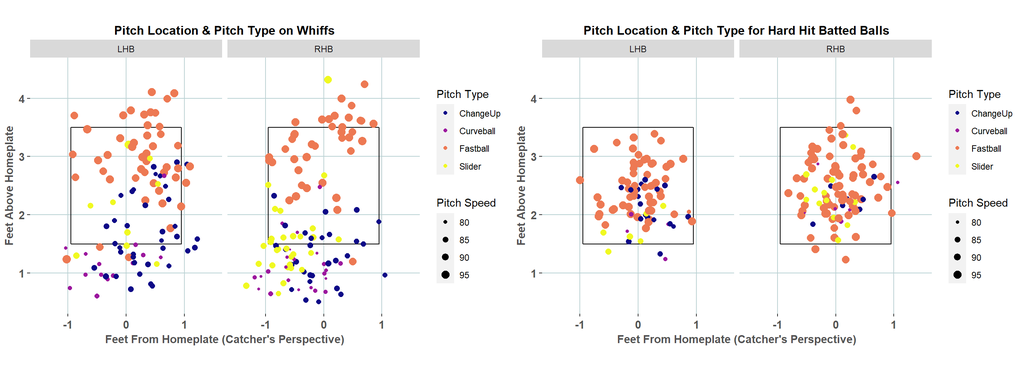

### Pitch Movement & Spin Axis

Below is a plot of his horizontal and induced vertical movement (inches) for each pitch type. It is important to note that the induced vertical movement component takes into account gravity so a pitch with 0 induced vertical component drops only as much as gravity forces to drop. Also included is a polar coordinate chart plotting spin direction in degrees. Since he mostly throws fastballs, it is hard to observe the other pitch types so I included another coordinate chart that removes fastballs. For reference, 180 degrees represents 12 o’clock tilt (backspin) while 360 degrees represents 6 o’clock tilt (topspin). A possible area for improvement is to introduce more horizontal movement and less vertical movement on the slider. Some of the best pitchers in the game have quick snapping sliders with upwards of 10 inches of horizontal movement. For our pitcher, I think it is a good idea to have batters see two pitch types (fastball and changeup) moving inside to righties and two pitch types (curveball and slider) moving away from righties. Right now, he is throwing sliders with almost no movement, otherwise known as gyro spin sliders. Even though the slider is an inefficient pitch in terms of spin efficiency, I believe he can still improve on his slider by changing tilt from an average of 150 degrees or 11 o’clock closer to 90 degrees or 9 o’clock and increasing spin. That should force the ball to move more laterally and less vertically which is what we want sliders to do. Making this adjustment can lead to higher whiff rates and an alternative to the over-used fastball.

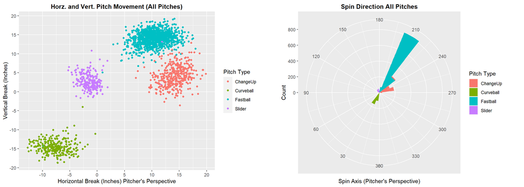

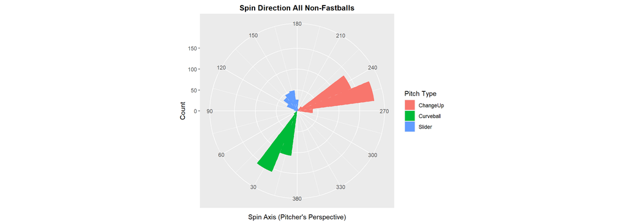

### Pitch Velocity & Spin Rate

For pitch velocity, we want to make sure he has some variability in speed among the different pitch types. Compared to fastballs, we expect to see average speed gap of -7 mph for sliders, -8 mph for changeups, and -14 mph for curveballs. Looking at his pitch velocity distribution, we see that holds for curveballs and sliders but his changeup speed gap from fastballs is about 10 mph which is even better than average. In terms of spin rate, our pitcher is similar to the average MLB spin rate for each pitch type. If our pitcher wants to increase velocity on his fastball, then a strength & conditioning program or weight training can increase velocity leading to increase in spin rate as well.

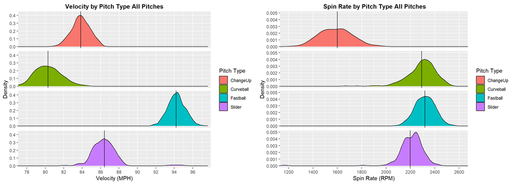

### Tables

I provided numerical tables to supplement the visualizations in the report. By looking at all four tables, we can infer that our pitcher struggles the most with his fastball, yet he throws that pitch most often. The fastball has a 47.2% hard hit rate while only having a 15.7% whiff rate. However, his best pitch is the changeup since it has the lowest hard hit rate and lowest line drive percentage while still maintaining a high whiff rate. However, he only throws the changeup 18% of the time. As mentioned previously, his slider has near zero movement and sliders typically have average spin axis at 90 degrees (9 o’clock), not 150 degrees (11 o’clock). There needs to be more separation in average spin axis from the fastball compared to the average spin axis of the slider. Looking at table values gives us a more numerical representation in the metrics compared to visualizations.

| Pitch Type | Velo | SpinRate | SpinAxis | HorzBreak | VertBreak |
| --- | --- | --- | --- | --- | --- |
| ChangeUp | 83.85 | 1599.47 | 253.88 | 14.19 | 4.17 |
| Curveball | 80.30 | 2291.71 | 27.74 | -7.65 | -14.53 |
| Fastball | 94.20 | 2318.27 | 216.21 | 10.48 | 14.04 |
| Slider | 86.41 | 2198.64 | 152.72 | -1.14 | 2.88 |

* Average Values All Pitches

| Pitch Type | Pitch Distribution | Whiff % |
| --- | --- | --- |
| Fastball | 58.7 | 15.7 |
| ChangeUp | 19.7 | 38.0 |
| Slider | 12.0 | 38.4 |
| Curveball | 9.7 | 51.6 |

* Batter Swings Only

| Pitch Type | Pitch Distribution | BABIP | Hard Hit % |
| --- | --- | --- | --- |
| Fastball | 65.5 | 0.336 | 47.2 |
| ChangeUp | 18.1 | 0.400 | 32.8 |
| Slider | 10.3 | 0.378 | 43.2 |
| Curveball | 6.1 | 0.364 | 40.9 |

* Batted Balls in Play Only

| Pitch Type | FB % | GB % | LD % | PU % |
| --- | --- | --- | --- | --- |
| ChangeUp | 21.5 | 55.4 | 20.0 | 3.1 |
| Curveball | 4.8 | 66.7 | 28.6 | 0.0 |
| Fastball | 29.2 | 39.5 | 23.6 | 7.7 |
| Slider | 16.2 | 43.2 | 37.8 | 2.7 |

* Batted Balls in Play Only

### Recommendation/Plan

- Improve Command/Pitch Execution
  - Needs more practice in his ability to locate pitches on the edges and corners of the plate and away from the middle.
  - Fastballs down the middle are being hit hard most often.
- Improve Slider
  - Currently acts like a gyro ball. That would not be an issue if he is having success getting batters out but his slider is still getting hit hard and is not a go-to strikeout pitch.
  - Advise to lower tilt to about 9 o’clock to get the ball to move more laterally (5-10 inches horizontal movement) with almost no vertical movement.
- Pitch Sequencing/Arsenal
  - Minimize relying on the fastball ahead in counts (0-2, 1-2) and implement more changeups, curveballs, or sliders low and away from the zone.
  - Experiment with throwing less fastballs in general and more change-ups while mixing in curveballs and sliders.

### Appendix

If interested, I also looked into the relationship between movement and velocity as well as plotting release points to check for any tipping of pitches or patterns in release points that hitters can find.

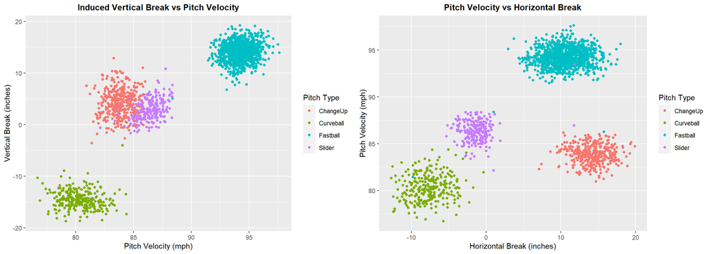

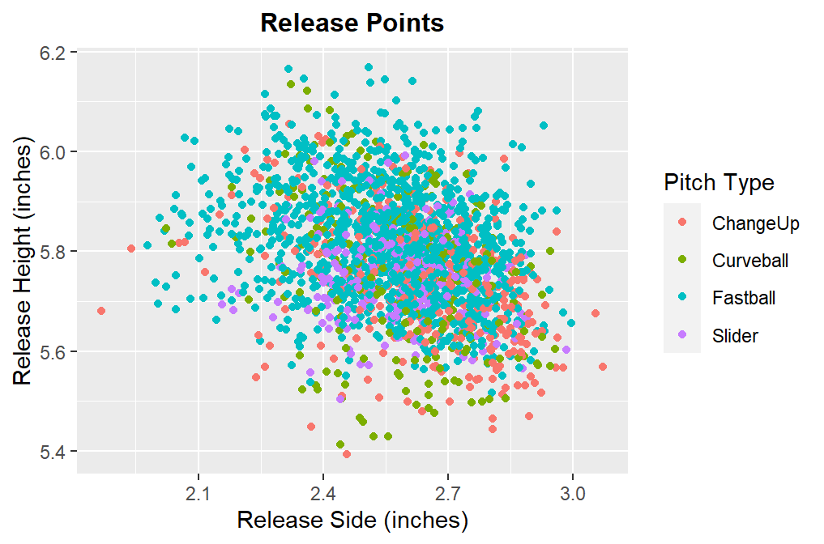